# 7_Clustering temporal: hora, dia semana, demanda y precio medio

# 7.1. Cluster con las variables mes, precio medio y hora

# Nota: estos resultados corresponden al apartado 2.6.4. K-means precio medio , mes y demanda

```r
clus_12<-electricity_prices[,c("Month", "PM", "Hour", "dem")]
clus_mh<-clus_12
```

```r
clus_mh[,c("Month")]<-(clus_12$Month-mean(clus_12$Month))/sd(clus_12$Month)
clus_mh[,c("PM")]<-(clus_12$PM-mean(clus_12$PM))/sd(clus_12$PM)
clus_mh[,c("Hour")]<-(clus_12$Hour-mean(clus_12$Hour))/sd(clus_12$Hour)
clus_mh[,c("dem")]<-(clus_12$dem-mean(clus_12$dem))/sd(clus_12$dem)
```

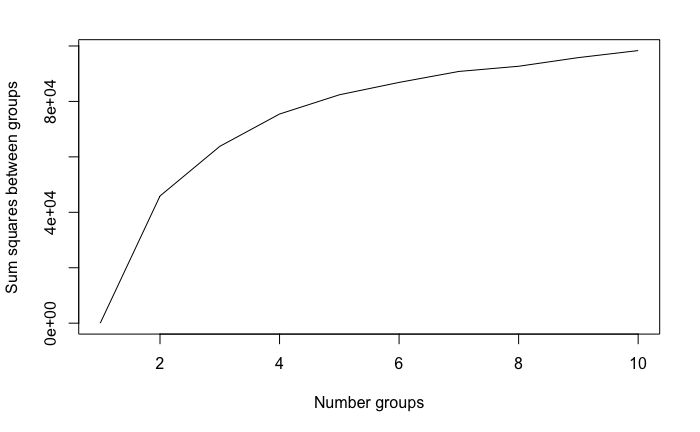

```r
set.seed(345)
bss_mh<-kmeans(clus_mh, centers=1)$betweenss
for(i in 2:10) bss_mh[i] <-kmeans(clus_mh, centers=i)$betweenss
plot(1:10, bss_mh, type="l", xlab="Number groups", ylab="Sum squares between groups")
```

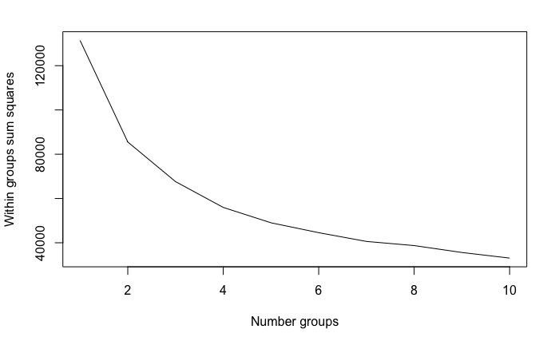

```r
set.seed(345)
bss_mh1<-kmeans(clus_mh, centers=1)$tot.withins
for(i in 2:10) bss_mh1[i] <-kmeans(clus_mh, centers=i)$tot.withins
plot(1:10, bss_mh1, type="l", xlab="Number groups", ylab="Within groups sum squares")
```

La solucion mas optima es k=4

```r
set.seed(345)
clusmh_k4<-kmeans(clus_mh, centers=4)
clusmh_k4$centers
```

```
       Month          PM       Hour        dem
1  0.6380827 -0.04111058 -1.0122374 -0.9485893
2 -0.9410945 -1.28854216 -0.7641242 -0.9246246
3  0.8462809  0.69684490  0.6348924  0.6273977
4 -0.8812428  0.04641317  0.6140207  0.6628926
```

```r
#Observamos la media con los valores sin estandarizar
aggregate(clus_12, by=list(clusmh_k4$cluster), mean)
```

| Group.1 | Month | PM | Hour | dem |
| --- | --- | --- | --- | --- |
| 1 | 8.358579 | 44.29102 | 5.493381 | 24050.24 |
| 2 | 3.071196 | 24.90890 | 7.210870 | 24159.64 |
| 3 | 9.055666 | 55.75710 | 16.895140 | 31244.43 |
| 4 | 3.271591 | 45.65094 | 16.750662 | 31406.46 |

Interpretacion:

- Cluster 1: Segundo semestre, precio intermedio, madrugada, demanda baja
- Cluster 2: Primer semestre, precio bajo, ma??ana, demanda baja
- Cluster 3: Segundo semestre, precio alto, tarde, demanda alta
- Cluster 4: Primer semestre, precio intermedio, tarde, demanda alta

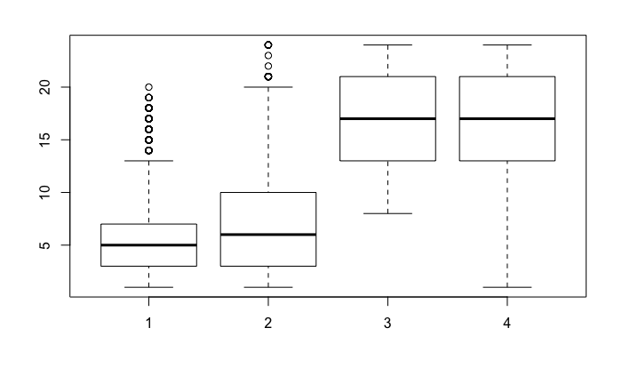

```r
#Observamos la distribucion de los clusters segun hora
boxplot(hour~clusmh_k4$cluster)
```

Como se ha interpretado anteriormente, los clusters 1 y 2 estan principalmente formados por el rango de horas de la ma??ana y los clusters 3 y 4 por la tarde.

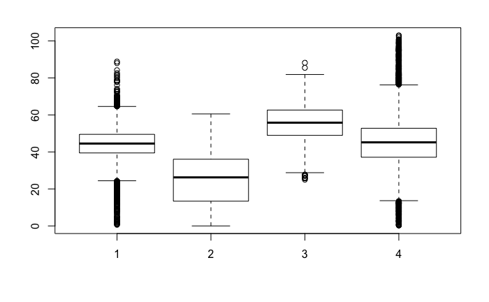

```r
#Observamos la distribucion de los clusters segun precio
boxplot(PM~clusmh_k4$cluster)
```

El precio mas bajo se da en el cluster 2 (Primer semestre, precio bajo, ma??ana, demanda baja) y los precios mas altos se dan con mas frecuencia en el cluster 3 (Segundo semestre, precio alto, tarde, demanda alta)

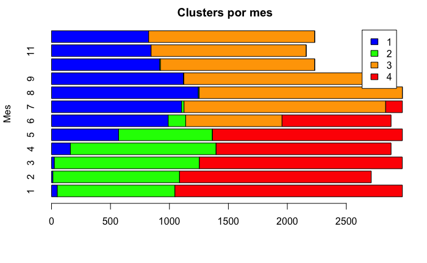

```r
#Observamos visualmente la distribucion por meses
ep_mes<-electricity_prices
ep_mes$cluster<-clusmh_k4$cluster
counts_mh <- table(ep_mes$cluster, electricity_prices$Month)
barplot(counts_mh, main="Clusters por mes", horiz=TRUE,
  ylab="Mes", col=c("blue", "green", "orange", "red"),
    legend = rownames(counts_mh))
```

```r
#Recuento de observaciones por cluster
table(ep_mes$cluster)
```

```
    1     2     3     4
 7856  5520 10042  9437
```

```r
#Representamos la distribucion de los clusters en un scatter plot con precio y demanda donde los colores marcan los clusters
clusters_mh<-clusmh_k4$cluster #Creamos variable con categorias de clusters
clusters_mh$clusters<-ifelse(clusmh_k4$cluster==1, "cluster 1",
                          ifelse (clusmh_k4$cluster==2, "cluster 2",
                            ifelse (clusmh_k4$cluster==3, "cluster 3",
                              "cluster 4")))
```

```
Coercing LHS to a list
```

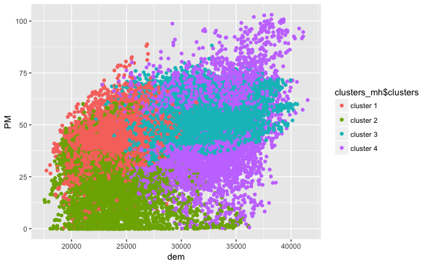

```r
#Observamos la distribucion de los clusters segun precio y demanda
f_mh1<-ggplot(electricity_prices, aes(x=dem, y=PM, col=clusters_mh$clusters))+geom_point()
f_mh1
```

# 7.2. Clustering mes, dia semana y hora

```r
clus_mhd<-electricity_prices[,c("Month", "PM", "Hour","weekend", "festivo","laborable", "dem")]
clus_mhd1<-clus_mhd
```

```r
clus_mhd1[,c("Month")]<-(clus_mhd$Month-mean(clus_mhd$Month))/sd(clus_mhd$Month)
clus_mhd1[,c("PM")]<-(clus_mhd$PM-mean(clus_mhd$PM))/sd(clus_mhd$PM)
clus_mhd1[,c("Hour")]<-(clus_mhd$Hour-mean(clus_mhd$Hour))/sd(clus_mhd$Hour)
clus_mhd1[,c("dem")]<-(clus_mhd$dem-mean(clus_mhd$dem))/sd(clus_mhd$dem)
clus_mhd1[,c("weekend")]<-(clus_mhd$weekend-mean(clus_mhd$weekend))/sd(clus_mhd$weekend)
clus_mhd1[,c("festivo")]<-(clus_mhd$festivo-mean(clus_mhd$festivo))/sd(clus_mhd$festivo)
clus_mhd1[,c("laborable")]<-(clus_mhd$laborable-mean(clus_mhd$laborable))/sd(clus_mhd$laborable)
```

```r
set.seed(345)
bss_mhd<-kmeans(clus_mhd1, centers=1)$betweenss
for(i in 2:10) bss_mhd[i] <-kmeans(clus_mhd1, centers=i)$betweenss
```

```
Quick-TRANSfer stage steps exceeded maximum (= 1642750)
```

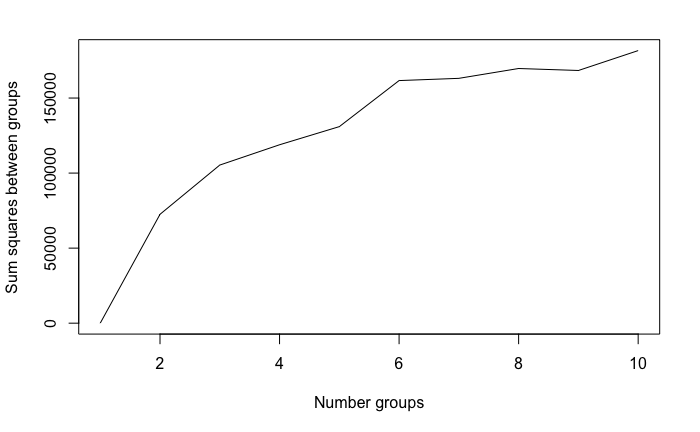

```r
plot(1:10, bss_mhd, type="l", xlab="Number groups", ylab="Sum squares between groups")
```

```r
#Relizamos k-means con k=6
set.seed(345)
clusmhd_k6<-kmeans(clus_mhd1, centers=6)
clusmhd_k6$centers
```

```
         Month         PM          Hour     weekend    festivo  laborable        dem
1  0.367199987 -0.2078064 -4.177131e-05  0.01048125  6.5695230 -1.5214904 -1.0199147
2  0.002900125 -0.3813590 -1.168206e+00 -0.63225053 -0.1522134  0.6572303 -0.8990636
3 -0.702715768 -0.5084067  7.163088e-01 -0.63225053 -0.1522134  0.6572303  0.6242565
4 -0.019602933 -0.3693152 -3.346578e-03  1.58160337 -0.1522134 -1.5214904 -0.6141695
5  0.866628335  0.7794097  5.334868e-01 -0.63225053 -0.1522134  0.6572303  0.7857907
6 -1.077694014  0.9731270  2.778235e-01 -0.60920504 -0.1522134  0.6345505  1.2552252
```

```r
#Observamos los resultados sin normalizar
aggregate(clus_mhd, by=list(clusmhd_k6$cluster), mean)
```

| Group.1 | Month | PM | Hour | weekend | festivo | laborable | dem |
| --- | --- | --- | --- | --- | --- | --- | --- |
| 1 | 7.451613 | 41.70097 | 12.500000 | 0.29032258 | 1 | 0.0000000 | 23724.65 |
| 2 | 6.231868 | 39.00437 | 4.413736 | 0.00000000 | 0 | 1.0000000 | 24276.32 |
| 3 | 3.869333 | 37.03035 | 17.458721 | 0.00000000 | 0 | 1.0000000 | 31230.09 |
| 4 | 6.156524 | 39.19151 | 12.477123 | 1.00000000 | 0 | 0.0000000 | 25576.83 |
| 5 | 9.123793 | 57.03996 | 16.193191 | 0.00000000 | 0 | 1.0000000 | 31967.47 |
| 6 | 2.613835 | 60.04987 | 14.423439 | 0.01040967 | 0 | 0.9895903 | 34110.38 |

La variable mes no ayuda a definir los clusters, la omitimos en el siguiente analisis

# 7.3. Clustering dia semana y hora

```r
clus_hd<-electricity_prices[,c("PM", "Hour","weekend", "festivo","laborable", "dem")]
clus_hd1<-clus_hd
```

```r
clus_hd1[,c("PM")]<-(clus_hd$PM-mean(clus_hd$PM))/sd(clus_hd$PM)
clus_hd1[,c("Hour")]<-(clus_hd$Hour-mean(clus_hd$Hour))/sd(clus_hd$Hour)
clus_hd1[,c("dem")]<-(clus_hd$dem-mean(clus_hd$dem))/sd(clus_hd$dem)
clus_hd1[,c("weekend")]<-(clus_hd$weekend-mean(clus_hd$weekend))/sd(clus_hd$weekend)
clus_hd1[,c("festivo")]<-(clus_hd$festivo-mean(clus_hd$festivo))/sd(clus_hd$festivo)
clus_hd1[,c("laborable")]<-(clus_hd$laborable-mean(clus_hd$laborable))/sd(clus_hd$laborable)
```

# 7.3.1. Seed=345

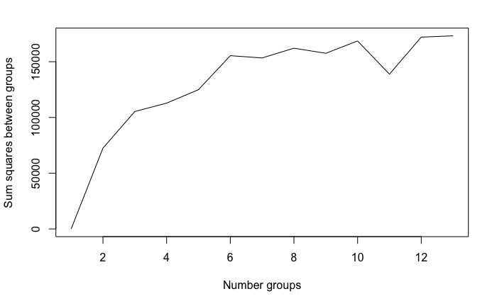

```r
set.seed(345)
bss_hd<-kmeans(clus_hd1, centers=1)$betweenss
for(i in 2:13) bss_hd[i] <-kmeans(clus_hd1, centers=i)$betweenss
plot(1:13, bss_hd, type="l", xlab="Number groups", ylab="Sum squares between groups")
```

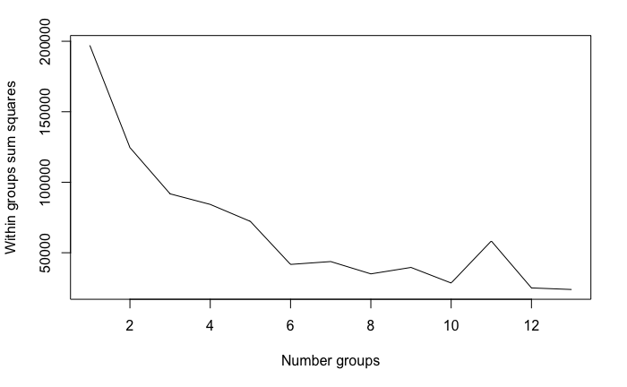

```r
set.seed(345)
bss_hd1<-kmeans(clus_hd1, centers=1)$tot.withins
for(i in 2:13) bss_hd1[i] <-kmeans(clus_hd1, centers=i)$tot.withins
plot(1:13, bss_hd1, type="l", xlab="Number groups", ylab="Within groups sum squares")
```

```r
#Relizamos k-means con k=6
set.seed(345)
clushd_k6<-kmeans(clus_hd1, centers=6)
clushd_k6$centers
```

```
          PM       Hour    weekend    festivo  laborable        dem
1 -0.6121300 -0.8808054  1.3000728  1.0522596 -1.5214904 -1.2121047
2 -0.4134691 -1.1741075 -0.6322505 -0.1522134  0.6572303 -0.9275766
3 -0.6773253  0.6409720 -0.6322505 -0.1522134  0.6572303  0.7210796
4 -0.1578298  0.6351905  1.5816034 -0.1522134 -1.5214904 -0.2261960
5  0.8238247 -0.1473491 -0.6322505 -0.1522134  0.6572303  0.9095137
6  0.7879260  1.1487560 -0.6322505 -0.1522134  0.6572303  0.7848407
```

```r
#Observamos los resultados sin normalizar
aggregate(clus_hd, by=list(clushd_k6$cluster), mean)
```

| Group.1 | PM | Hour | weekend | festivo | laborable | dem |
| --- | --- | --- | --- | --- | --- | --- |
| 1 | 35.41874 | 6.403179 | 0.8728324 | 0.1791908 | 0 | 22847.33 |
| 2 | 38.50546 | 4.372884 | 0.0000000 | 0.0000000 | 1 | 24146.16 |
| 3 | 34.40576 | 16.937225 | 0.0000000 | 0.0000000 | 1 | 31672.07 |
| 4 | 42.47749 | 16.897204 | 1.0000000 | 0.0000000 | 0 | 27347.88 |
| 5 | 57.73006 | 11.480310 | 0.0000000 | 0.0000000 | 1 | 32532.25 |
| 6 | 57.17228 | 20.452207 | 0.0000000 | 0.0000000 | 1 | 31963.14 |

Interpretacion:

Conclusion: fines de semana y festivos, el precio es mas bajo por la ma??ana que por la tarde (asi como la demanda). Los dias laborables, el precio es mas bajo durante la madrugada y la tarde y mas alto durante la ma??ana y la noche (aproximadamente de 19:00 a 22:00)

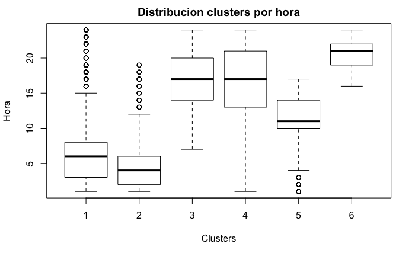

```r
#Analisis distribucion por hora
boxplot(hour~clushd_k6$cluster, main = "Distribucion clusters por hora", xlab= "Clusters", ylab= "Hora")
```

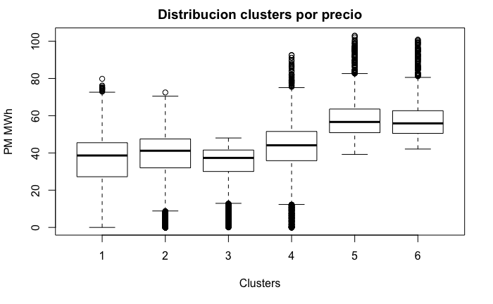

```r
#Analisis distribucion por hora
boxplot(PM~clushd_k6$cluster, main = "Distribucion clusters por precio", xlab= "Clusters", ylab= "PM MWh")
```

# 7.3.2. Seed=123

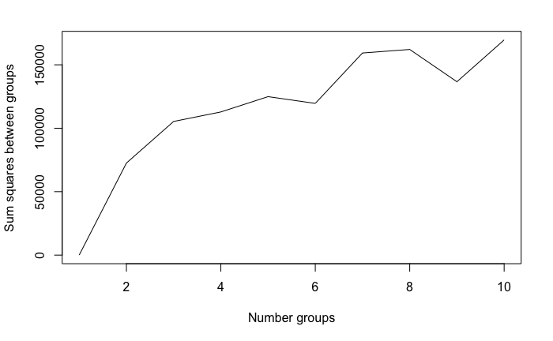

```r
set.seed(123)
bss_hd1<-kmeans(clus_hd1, centers=1)$betweenss
for(i in 2:10) bss_hd1[i] <-kmeans(clus_hd1, centers=i)$betweenss
plot(1:10, bss_hd1, type="l", xlab="Number groups", ylab="Sum squares between groups")
```

Con esta semilla, el numero de grupos mas optimo parece ser 7 clusters.

```r
#Relizamos k-means con k=7 y semilla = 123
set.seed(123)
clushd_k7_1<-kmeans(clus_hd1, centers=7)
clushd_k7_1$centers
```

```
           PM        Hour    weekend    festivo  laborable        dem
1 -0.94310649  0.52916152 -0.6322505 -0.1522134  0.6572303  0.8295996
2  0.04769943 -1.17069631 -0.6322505 -0.1522134  0.6572303 -0.8508468
3  1.37911132  0.65659422 -0.6140565 -0.1522134  0.6393249  1.4557530
4 -0.35445397 -0.00233692  1.4642122  0.3511346 -1.5214904 -0.6433286
5  0.57246449 -0.14102726 -0.6322505 -0.1522134  0.6572303  0.7824130
6 -1.55843457 -1.16126030 -0.6322505 -0.1384323  0.6527634 -1.0867133
7  0.36156564  1.19725811 -0.6322505 -0.1522134  0.6572303  0.4766409
```

```r
#Observamos los resultados sin normalizar
aggregate(clus_hd, by=list(clushd_k7_1$cluster), mean)
```

| Group.1 | PM | Hour | weekend | festivo | laborable | dem |
| --- | --- | --- | --- | --- | --- | --- |
| 1 | 30.27615 | 16.163250 | 0.000000000 | 0.000000000 | 1.0000000 | 32167.45 |
| 2 | 45.67092 | 4.396497 | 0.000000000 | 0.000000000 | 1.0000000 | 24496.43 |
| 3 | 66.35790 | 17.045365 | 0.008218277 | 0.000000000 | 0.9917817 | 35025.77 |
| 4 | 39.42241 | 12.484113 | 0.946974297 | 0.074883627 | 0.0000000 | 25443.72 |
| 5 | 53.82452 | 11.524070 | 0.000000000 | 0.000000000 | 1.0000000 | 31952.05 |
| 6 | 20.71542 | 4.461814 | 0.000000000 | 0.002050231 | 0.9979498 | 23419.73 |
| 7 | 50.54766 | 20.787948 | 0.000000000 | 0.000000000 | 1.0000000 | 30556.24 |

Esta vez, al cambiar la semilla, los resultados tambien son diferentes: -Cluster 1: precio bajo, tarde, laborable, demanda alta -Cluster 2: precio medio, madrugada, laborable, demanda baja -Cluster 3: Precio muy alto, tarde, laborable y fin de semana, demanda muy alta -Cluster 4: Precio bajo, mediod??a, fin de semana y festivos, demanda baja -Cluster 5: precio alto, ma??ana, laborable, demanda alta -Cluster 6: precio muy bajo, madrugada, festivos y laborables, demanda baja -Cluster 7: precio alto, noche, laborable, demanda alta

Los grupos parecen mas heterogeneos en la solucion con semilla 345, por lo tanto nos quedaremos con los resultados anteriores

```r
#Recuento observaciones en cada cluster
table(clushd_k7_1$cluster)
```

```
   1    2    3    4    5    6    7
2732 5309 3042 9882 5110 1951 4829
```

Grupos mas minoritarios: clusters 1 y 6 (precio bajo).

# 7.3.3. Seed=12345

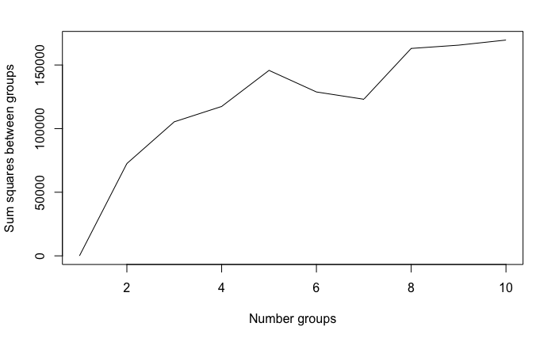

```r
set.seed(12345)
bss_hd2<-kmeans(clus_hd1, centers=1)$betweenss
for(i in 2:10) bss_hd2[i] <-kmeans(clus_hd1, centers=i)$betweenss
plot(1:10, bss_hd2, type="l", xlab="Number groups", ylab="Sum squares between groups")
```

Con esta semilla, el numero de grupos mas optimo parece ser 5 clusters.

```r
#Relizamos k-means con k=5 y semilla = 12345
set.seed(12345)
clushd_k5_2<-kmeans(clus_hd1, centers=5)
clushd_k5_2$centers
```

```
          PM       Hour    weekend    festivo  laborable        dem
1 -0.3163096  0.8229643 -0.6322505 -0.1522134  0.6572303  0.6494293
2 -0.6121300 -0.8808054  1.3000728  1.0522596 -1.5214904 -1.2121047
3  0.9777071  0.3491576 -0.6322505 -0.1522134  0.6572303  0.9843519
4 -0.1578298  0.6351905  1.5816034 -0.1522134 -1.5214904 -0.2261960
5 -0.3747858 -1.1498041 -0.6322505 -0.1522134  0.6572303 -0.8766547
```

```r
#Observamos los resultados sin normalizar
aggregate(clus_hd, by=list(clushd_k5_2$cluster), mean)
```

| Group.1 | PM | Hour | weekend | festivo | laborable | dem |
| --- | --- | --- | --- | --- | --- | --- |
| 1 | 40.01509 | 18.197012 | 0.0000000 | 0.0000000 | 1 | 31345.00 |
| 2 | 35.41874 | 6.403179 | 0.8728324 | 0.1791908 | 0 | 22847.33 |
| 3 | 60.12103 | 14.917228 | 0.0000000 | 0.0000000 | 1 | 32873.88 |
| 4 | 42.47749 | 16.897204 | 1.0000000 | 0.0000000 | 0 | 27347.88 |
| 5 | 39.10651 | 4.541117 | 0.0000000 | 0.0000000 | 1 | 24378.62 |

Interpretacion:

- Cluster 1: precio medio, tarde, laborable, demanda alta.
- Cluster 2: precio bajo, madrugada, fin de semana y festivo, demanda baja
- Cluster 3: precio alto, mediodia, laborable, demanda alta
- Cluster 4: precio medio, tarde, fin de semana, demanda baja
- Cluster 5: precio bajo, madrugada, laborable, demanda baja

De nuevo, nos quedamos con la solucion del apartado 7.3.1